# 14. Meta-algoritmi

Jekaterīna Butkeviča

2026-01-10

## Uzdevums

1. Atrodiet internetā kādu interesantu datu kopu klasifikācijas uzdevumam (ja nekas cits neatrodas, izmantojiet kādu no WEKAs datu kopām vai iepriekšējo mājas darbu datu kopas).
2. Izvēlieties vienu no variantiem (vai abus): a) RandomForest, b) AdaBoost (vai kādu no jaunākiem “būsteriem”, piemēŗam, XGBoost). Pirmais eksperiments: palielinot iterāciju skaitu, mēģiniet treniņa kopā sasniegt 100% klasifikācijas precizitāti.
3. Otrais: mainot visus pieejamos parametrus, mēģiniet sasniegt pēc iespējas labāku rezultātu kros-validācijas režīmā.

## Pirmais eksperiments

**Uzdevums:** palielinot iterāciju skaitu, mēģiniet treniņa kopā sasniegt 100% klasifikācijas precizitāti.

### RandomForest

Pielitoju algoritmu RandomForest ar sekojošiem iestatījumiem:

- bagSizePercent = 100;
- maxDepth = 0;
- numFeatures = 0.

Pārbaudes veids: Use training set

Veicu 15 mēģinājumus, pierakstu rezultātus datu tabulā:

```r
RF1 <- data.frame(
  Iteracijas = c(1, 2, 3, 4, 5, 6, 7, 8, 9, 10, 11, 12, 13, 14, 15),
  Precizitate = c(97.7208, 98.2906, 98.5755, 99.4302, 99.1453, 99.7151, 99.7151, 100, 99.7151, 100, 99.7151, 100, 99.7151, 99.7151, 99.7151)
  )
```

Vizualizēju rezultātus:

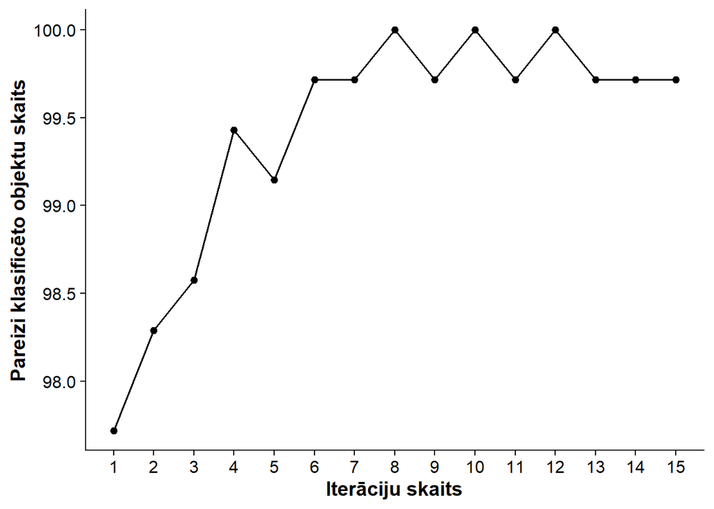

```r
library(ggplot2)
library(cowplot)

ggplot(RF1, aes(x = Iteracijas, y = Precizitate)) +
  geom_line() +
  geom_point() +
  scale_x_continuous(breaks = 1:15) +
  labs(
    x = "Iterāciju skaits",
    y = "Pareizi klasificēto objektu skaits"
  ) +
  theme_half_open() +
  theme(
    axis.title.x = element_text(face = "bold"),  # X ass nosaukums treknrakstā
    axis.title.y = element_text(face = "bold")   # Y ass nosaukums treknrakstā
  )
```

Izmantojot RandomForest algoritmu ar augstāk pieminētajiem iestātījumiem, precizitāti 100% pirmo reizi izdevas sasniegt pie iterāciju skata vienādu ar 8, bet turpinot palielināt iterāciju skaitu tā periodiski mījas staarp 100% un 99.72%, līdz pārstāja mainīties (3 mēģinājumi) pie vērtības 99.72%.

### AdaBoost

Pielietoju algoritmu AdaBoost ar sēkojošiem iestatījumiem:

- kā bāzes algoritmu izmanotju J48;
- useResampling = False.

Pārbaudes veids: Use training set

Veicu 15 mēģinājumus, pierakstu rezultātus datu tabulā:

```r
AB1 <- data.frame(
  Iteracijas = c(1, 2, 3, 4, 5, 6, 7, 8, 9, 10, 11, 12, 13, 14, 15),
  Precizitate = c(99.7151, 99.7151, 100, 100, 100, 100, 100, 100, 100, 100, 100, 100, 100, 100, 100)
  )
```

Vizualizēju rezultātus:

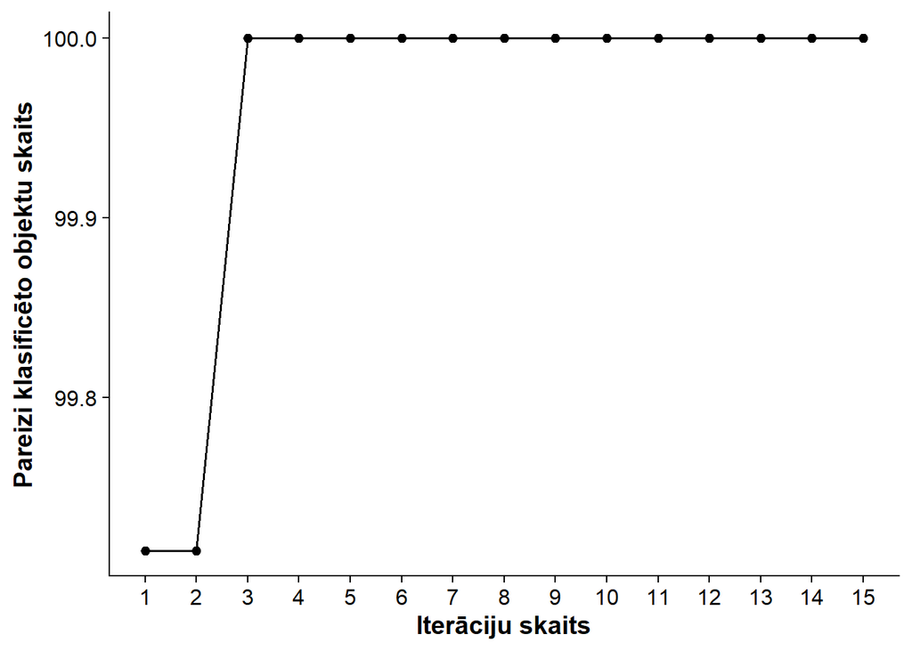

```r
ggplot(AB1, aes(x = Iteracijas, y = Precizitate)) +
  geom_line() +
  geom_point() +
  scale_x_continuous(breaks = 1:15) +
  labs(
    x = "Iterāciju skaits",
    y = "Pareizi klasificēto objektu skaits"
  ) +
  theme_half_open() +
  theme(
    axis.title.x = element_text(face = "bold"),  # X ass nosaukums treknrakstā
    axis.title.y = element_text(face = "bold")   # Y ass nosaukums treknrakstā
  )
```

Ar meta-algoritmu AdaBoost precizitāte 100% tika sasniegta pie trim iterācijam un palika tāda arī palielinot iterāciju skaitu.

## Otrais eksperiments

**Uzdevums:** mainot visus pieejamos parametrus, mēģiniet sasniegt pēc iespējas labāku rezultātu kros-validācijas režīmā.

### RandomForest

Pielitoju algoritmu RandomForest ar sekojošiem iestatījumiem:

1. meģinājums
- bagSizePercent = 100;
- maxDepth = 0;
- numIterations = 1;
- numFeatures = 0.
2. meģinājums
- bagSizePercent = 100;
- maxDepth = 0;
- numIterations = 5;
- numFeatures = 0.
3. meģinājums
- bagSizePercent = 100;
- maxDepth = 0;
- numIterations = 10;
- numFeatures = 0.
4. meģinājums
- bagSizePercent = 100;
- maxDepth = 0;
- numIterations = 100;
- numFeatures = 0.
5. meģinājums
- bagSizePercent = 100;
- maxDepth = 0;
- numIterations = 1;
- numFeatures = 10.
6. meģinājums
- bagSizePercent = 100;
- maxDepth = 0;
- numIterations = 1;
- numFeatures = 50.
7. meģinājums
- bagSizePercent = 100;
- maxDepth = 0;
- numIterations = 1;
- numFeatures = 100.
8. meģinājums
- bagSizePercent = 100;
- maxDepth = 0;
- numIterations = 5;
- numFeatures = 10.
9. meģinājums
- bagSizePercent = 100;
- maxDepth = 0;
- numIterations = 10;
- numFeatures = 50.
10. meģinājums
- bagSizePercent = 100;
- maxDepth = 0;
- numIterations = 100;
- numFeatures = 100.
11. meģinājums
- bagSizePercent = 80;
- maxDepth = 0;
- numIterations = 100;
- numFeatures = 100.
12. meģinājums
- bagSizePercent = 70;
- maxDepth = 0;
- numIterations = 100;
- numFeatures = 100.
13. meģinājums
- bagSizePercent = 80;
- maxDepth = 0;
- numIterations = 200;
- numFeatures = 100.
14. meģinājums
- bagSizePercent = 75;
- maxDepth = 0;
- numIterations = 100;
- numFeatures = 100.
15. meģinājums
- bagSizePercent = 50;
- maxDepth = 0;
- numIterations = 1000;
- numFeatures = 100.

Visos gādījumos pārbaudes veids: Cross-validation

Veicu 15 mēģinājumus, pierakstu rezultātus datu tabulā:

```r
RF2 <- data.frame(
  Meginajums = c(1, 2, 3, 4, 5, 6, 7, 8, 9, 10, 11, 12, 13, 14, 15),
  Precizitate = c(87.1795, 91.1681, 92.8775, 92.8775, 84.6154, 87.1795, 87.1795, 92.0228, 92.0228, 92.8775, 93.7322, 93.4473, 93.1624, 93.7322, 93.1624)
  )
```

Vizualizēju rezultātus:

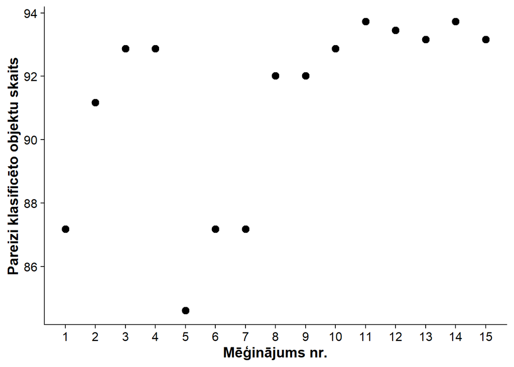

```r
ggplot(RF2, aes(x = Meginajums, y = Precizitate)) +
  geom_point(size = 3) +
  scale_x_continuous(breaks = 1:15) +
  labs(
    x = "Mēģinājums nr.",
    y = "Pareizi klasificēto objektu skaits"
  ) +
  theme_half_open() +
  theme(
    axis.title.x = element_text(face = "bold"),  # X ass nosaukums treknrakstā
    axis.title.y = element_text(face = "bold")   # Y ass nosaukums treknrakstā
  )
```

Ar algoritmu randomForest, labāka sasniegta precizitāte ir 93.73%, kas tika sasniegta 11. un 14. mēginājumā.

### AdaBoost

Pielietoju algoritmu AdaBoost ar sēkojošiem iestatījumiem:

- kā bāzes algoritmu izmanotju J48;
1. meģinājums:
- batchSize = 100
- useResampling = False.
- numIterations = 10
2. meģinājums:
- batchSize = 100
- useResampling = False.
- numIterations = 50
3. meģinājums:
- batchSize = 100
- useResampling = False.
- numIterations = 100
4. meģinājums:
- batchSize = 90
- useResampling = False.
- numIterations = 100
5. meģinājums:
- batchSize = 80
- useResampling = False.
- numIterations = 100
6. meģinājums:
- batchSize = 50
- useResampling = False.
- numIterations = 100
7. meģinājums:
- batchSize = 50
- useResampling = False.
- numIterations = 100
- resume = TRUE
8. meģinājums:
- batchSize = 50
- useResampling = False.
- numIterations = 100
- resume = TRUE
- useResampling = TRUE
9. meģinājums:
- batchSize = 50
- useResampling = False.
- numIterations = 200
- resume = TRUE
- useResampling = TRUE
10. meģinājums:
- batchSize = 50
- useResampling = False.
- numIterations = 200
- resume = TRUE
- useResampling = TRUE
- weightThreshold = 80
11. meģinājums:
- batchSize = 50
- useResampling = False.
- numIterations = 200
- resume = TRUE
- useResampling = TRUE
- weightThreshold = 20

Visos gādījumos pārbaudes veids: Cross-validation

Veicu 11 mēģinājumus, pierakstu rezultātus datu tabulā:

```r
AB2 <- data.frame(
  Meginajums = c(1, 2, 3, 4, 5, 6, 7, 8, 9, 10, 11),
  Precizitate = c(93.1624, 93.4473, 93.7322, 93.7322, 93.7322, 93.7322, 93.7322, 94.8718, 94.8718, 94.302, 88.3191)
  )
```

Apstājos pie 11 mēģinājumiem, jo vairs nav ko mainīt. Uzskatu kā nebūtu korekti mainīt bazes algoritmu un salīdiznāt rezultātus savā starpa, tāpēc mainītie tika tikai parējie iestatījumi.

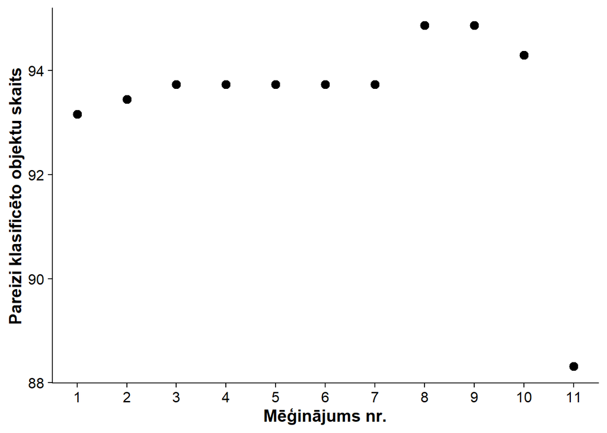

```r
ggplot(AB2, aes(x = Meginajums, y = Precizitate)) +
  geom_point(size = 3) +
  scale_x_continuous(breaks = 1:15) +
  labs(
    x = "Mēģinājums nr.",
    y = "Pareizi klasificēto objektu skaits"
  ) +
  theme_half_open() +
  theme(
    axis.title.x = element_text(face = "bold"),  # X ass nosaukums treknrakstā
    axis.title.y = element_text(face = "bold")   # Y ass nosaukums treknrakstā
  )
```

Ar AdaBoost algoritmu labāka precizitāte ir sasniegta 8. un 9. meģinājuma un ir vienāda ar 94.87%.